# Advanced ggplot homework

```r
library(tidyverse)
```

```r
library(CodeClanData)
```

# MVP

## Part 1

### 1. Take the data in the dataset qb_revenue_breakdown and make a stacked bar chart showing the sources of revenue across the two years in the dataset.

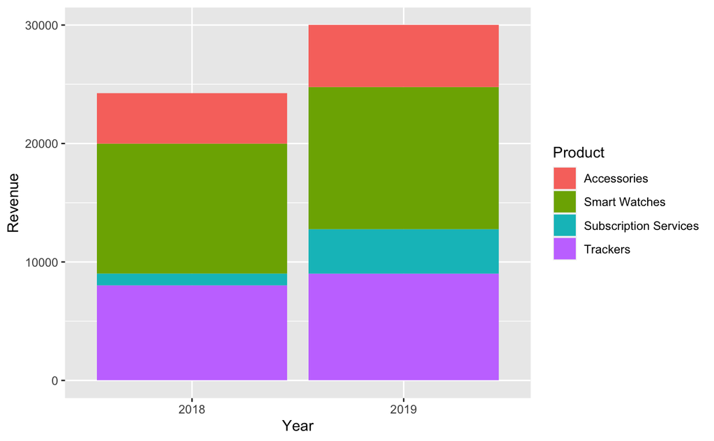

### 2. Make a line chart showing monthly sales of the “flagship product” - the ‘KwikBit Unit 1’ - over the last year. This data is inside qb_monthly_sales, but you will need to use filter() or subset() (base R).

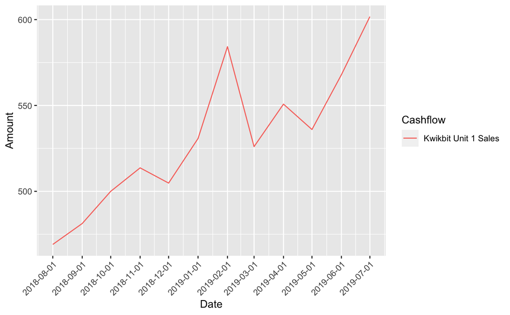

### 3. Make a line chart showing monthly revenue and costs over the last year. This data is also in qb_monthly_sales.

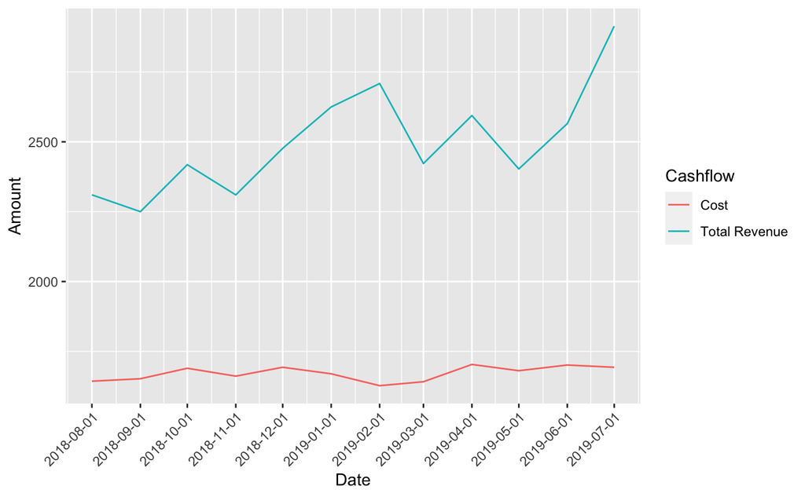

### 4. Show annual sales of personal fitness trackers over the last 5 years broken down by company as a ribbon plot (use geom_area). This data is in qb_competitors.

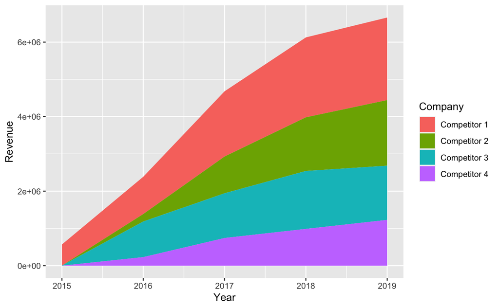

### 5. Now show the sales from the four competitors as a line graph. Include an extra layer that shows the data points used to make the lines.

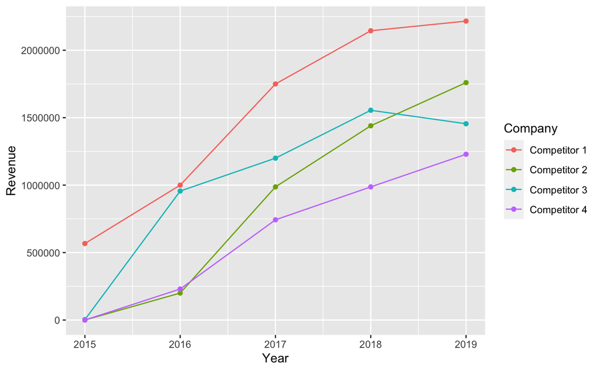

### 6. Now the company wants to compare the number of steps that their device counts vs. their competitors. Make a line graph of the number of steps throughout time, and use faceting to compare between companies and people. The data for this is in qb_device_data.

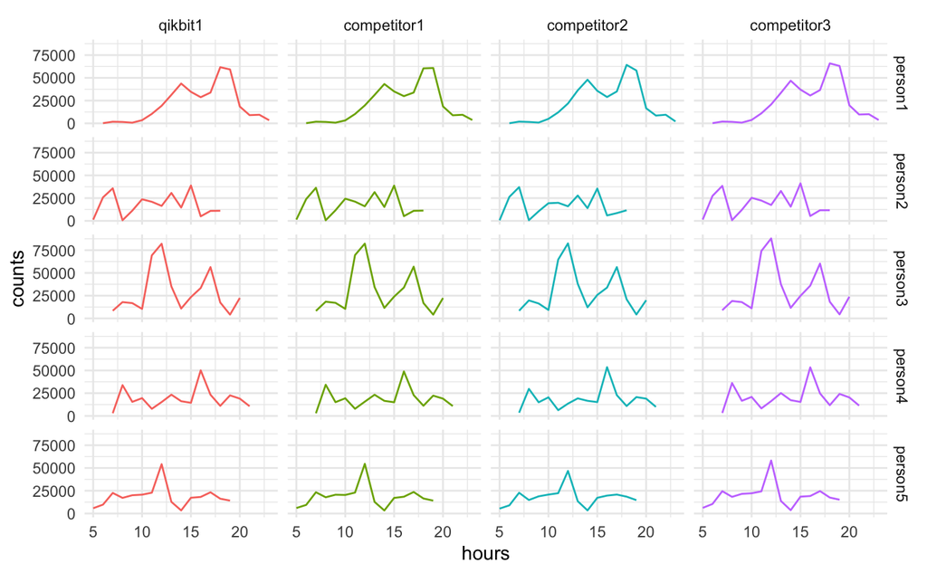

```r
device_data %>%
  group_by(device, id, hours) %>%
  summarise(counts = sum(counts)) %>%
  ggplot() +
    aes(x = hours, y = counts, colour = device) +
    geom_line() +
    facet_grid(id ~ device) +
    theme_minimal() +
    theme(legend.position = "none")
```

## Part 2

Take the plots that you produced in part one and now polish them by:

Adding appropriate labels

Changing the scales and coordinates when appropriate.

### 1,

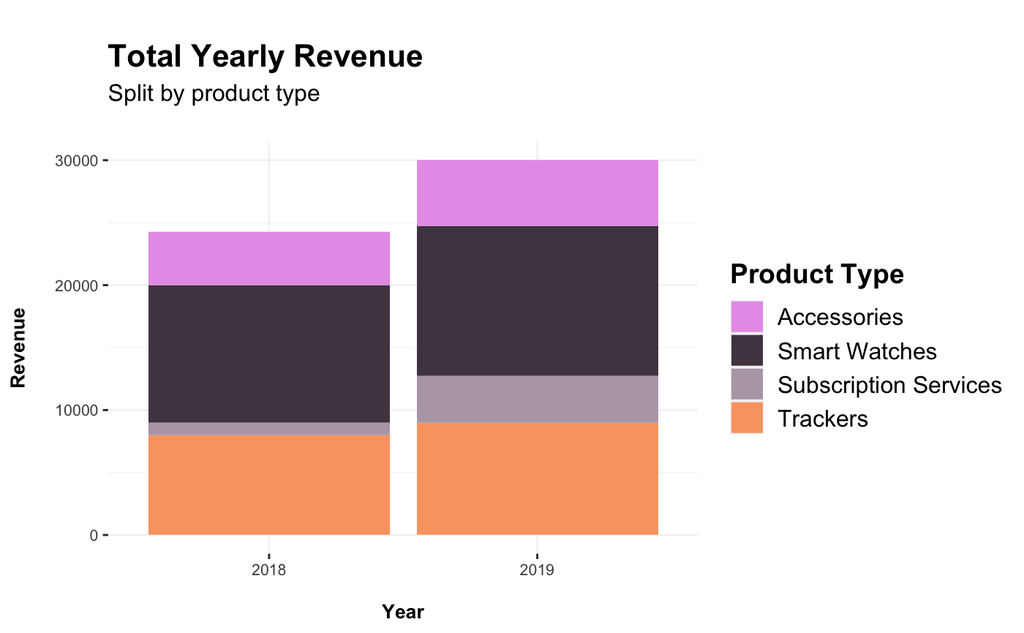

### 2.

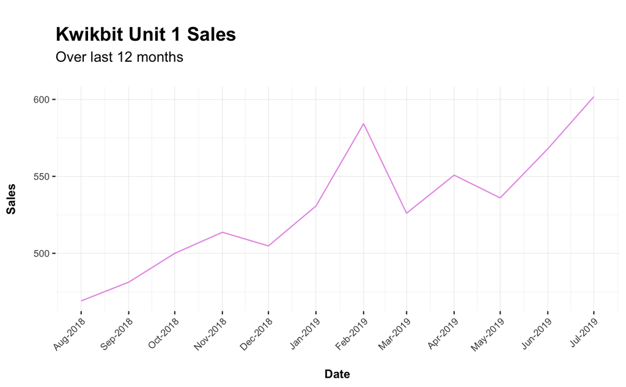

### 3.

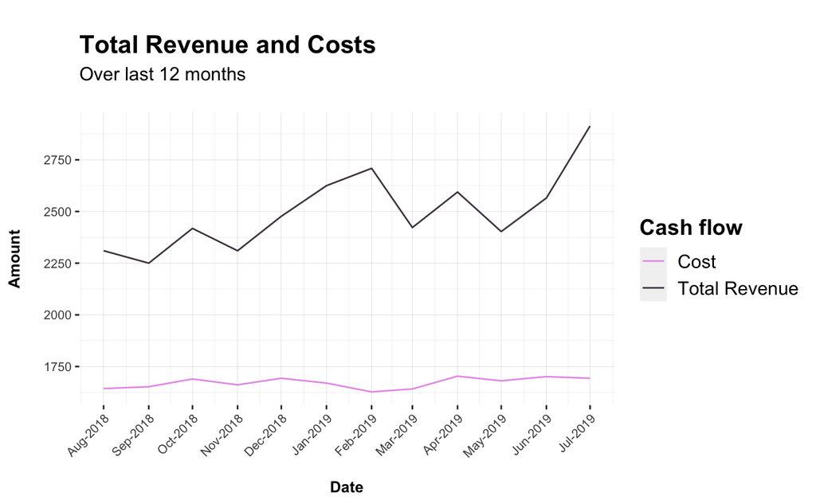

### 4.

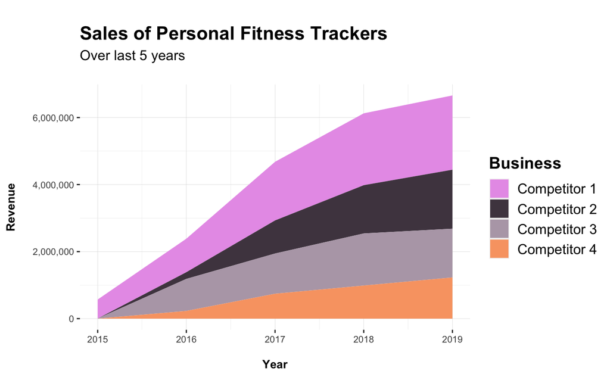

### 5.

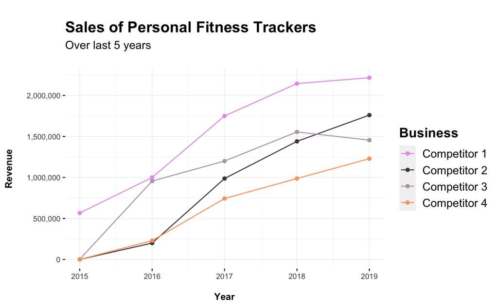

### 6.

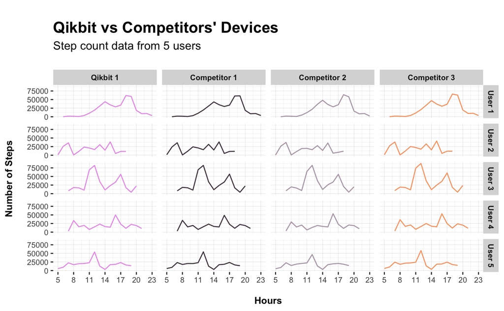

```r
device_data %>%
  # First total up number of steps per hour for each device/user combination
  group_by(device, id, hours) %>%
  summarise(counts = sum(counts)) %>%
  # Tidy up names
  mutate(
    device = case_when(
      device == "qikbit1" ~ "Qikbit 1",
      device == "competitor1" ~ "Competitor 1",
      device == "competitor2" ~ "Competitor 2",
      device == "competitor3" ~ "Competitor 3"
    ),
    id = case_when(
      id == "person1" ~ "User 1",
      id == "person2" ~ "User 2",
      id == "person3" ~ "User 3",
      id == "person4" ~ "User 4",
      id == "person5" ~ "User 5"
    ),
    # Order devices as factor for graph
    device = factor(device, levels = c("Qikbit 1", "Competitor 1", "Competitor 2", "Competitor 3"))
    ) %>%
  ggplot() +
    aes(x = hours, y = counts, colour = device) +
    geom_line() +
    # facet by user and device
    facet_grid(id ~ device) +
    # add labels
    labs(
      x = "\nHours",
      y = "Number of Steps\n",
      fill = "Business",
      title = "\nQikbit vs Competitors' Devices",
      subtitle = "Step count data from 5 users\n"
    ) +
    # change x axis breaks
    scale_x_continuous(breaks = c(5, 8, 11, 14, 17, 20, 23)) +
    # add theme elements
    theme(
      # remove legend
      legend.position = "none",
      plot.title = element_text(size = 16, face = "bold"),
      plot.subtitle = element_text(size = 12),
      axis.title = element_text(size = 10, face = "bold"),
      axis.text = element_text(size = 8),
      panel.background = element_rect(fill = "white"),
      panel.grid = element_line(colour = "light grey", size = 0.1),
      strip.text = element_text(size = 8, face = "bold")
    ) +
    scale_colour_manual(values = col_scheme)
```

# Extension

Try out different ways of plotting these three datasets. Which graphs do you think are particularly effective at showing QikBit’s success?

### Q1 but bar chart with dodge

```r
ggplot(revenue_breakdown) +
  aes(x = Year, y = Revenue, fill = Product) +
  geom_col(position = "dodge") +
  # add labels
  labs(
    x = "\nYear",
    y = "Revenue\n",
    title = "\nTotal Yearly Revenue",
    subtitle = "Split by product type\n",
    fill = "Product Type"
  ) +
  # add theme elements
  theme(
    plot.title = element_text(size = 16, face = "bold"),
    plot.subtitle = element_text(size = 12),
    legend.title = element_text(size = 14, face = "bold"),
    legend.text = element_text(size = 12),
    axis.title = element_text(size = 10, face = "bold"),
    axis.text = element_text(size = 8),
    panel.background = element_rect(fill = "white"),
    panel.grid = element_line(colour = "light grey", size = 0.1)
  ) +
  scale_fill_manual(values = col_scheme)
```

[output not shown]

### Q2 but bar chart

```r
monthly_sales %>%
  filter(Cashflow == "Kwikbit Unit 1 Sales") %>%
  ggplot() +
    aes(x = Date, y = Amount, fill = Cashflow) +
    geom_col() +
    # change x scale to monthly, in nice date format
    scale_x_date(breaks = "1 month", labels = scales::date_format("%b-%Y")) +
    # add labels
    labs(
      x = "\nDate",
      y = "Sales\n",
      title = "\nKwikbit Unit 1 Sales",
      subtitle = "Over last 12 months\n"
    ) +
    # add theme elements
    theme(
      # remove legend
      legend.position = "none",
      # rotate x axis 45 degrees and nudge down
      axis.text.x = element_text(angle = 45, hjust = 1),
      plot.title = element_text(size = 16, face = "bold"),
      plot.subtitle = element_text(size = 12),
      axis.title = element_text(size = 10, face = "bold"),
      axis.text = element_text(size = 8),
      panel.background = element_rect(fill = "white"),
      panel.grid = element_line(colour = "light grey", size = 0.1)
    ) +
    scale_fill_manual(values = col_scheme)
```

[output not shown]

### Q4/5 but bar chart with dodge

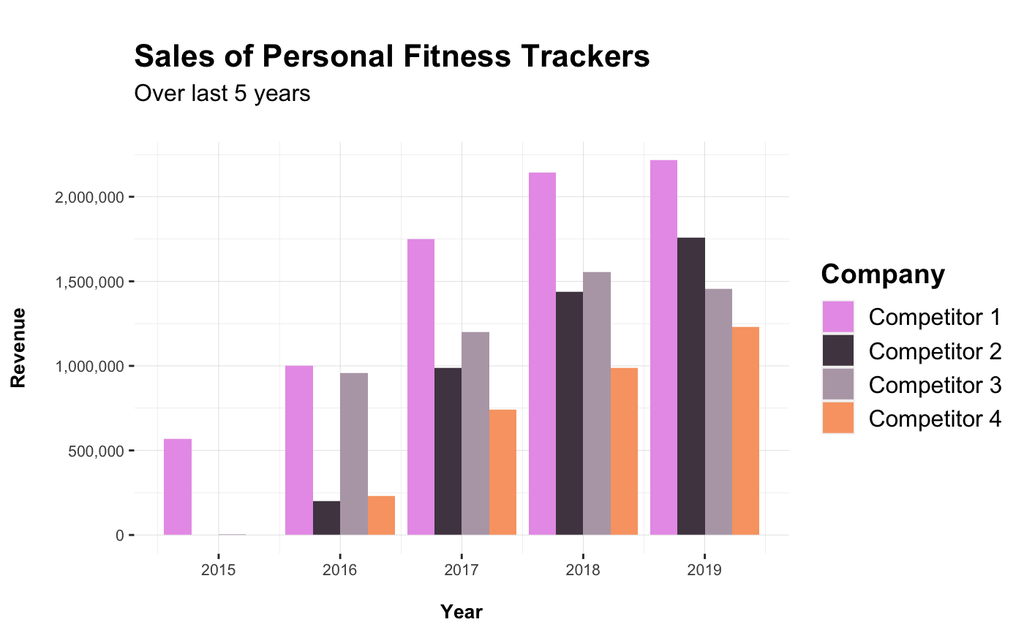

### Q6 but Histogram

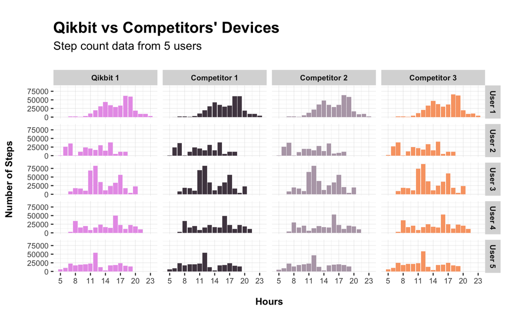

```r
device_data %>%
  # First total up number of steps per hour for each device/user combination
  group_by(device, id, hours) %>%
  summarise(counts = sum(counts)) %>%
  # Tidy up names
  mutate(
    device = case_when(
      device == "qikbit1" ~ "Qikbit 1",
      device == "competitor1" ~ "Competitor 1",
      device == "competitor2" ~ "Competitor 2",
      device == "competitor3" ~ "Competitor 3"
    ),
    id = case_when(
      id == "person1" ~ "User 1",
      id == "person2" ~ "User 2",
      id == "person3" ~ "User 3",
      id == "person4" ~ "User 4",
      id == "person5" ~ "User 5"
    ),
    # Order devices as factor for graph
    device = factor(device, levels = c("Qikbit 1", "Competitor 1", "Competitor 2", "Competitor 3"))
    ) %>%
  ggplot() +
    aes(x = hours, y = counts, fill = device) +
    geom_histogram(stat = "identity") +
    # facet by user and device
    facet_grid(id ~ device) +
    # add labels
    labs(
      x = "\nHours",
      y = "Number of Steps\n",
      fill = "Business",
      title = "\nQikbit vs Competitors' Devices",
      subtitle = "Step count data from 5 users\n"
    ) +
    # change x axis breaks
    scale_x_continuous(breaks = c(5, 8, 11, 14, 17, 20, 23)) +
    # add theme elements
    theme(
      # remove legend
      legend.position = "none",
      plot.title = element_text(size = 16, face = "bold"),
      plot.subtitle = element_text(size = 12),
      axis.title = element_text(size = 10, face = "bold"),
      axis.text = element_text(size = 8),
      panel.background = element_rect(fill = "white"),
      panel.grid = element_line(colour = "light grey", size = 0.1),
      strip.text = element_text(size = 8, face = "bold")
    ) +
    scale_fill_manual(values = col_scheme)
```